# Dog : Only Trustworthy

**Milind Singh**

**May 2020**

“WeRateDogs is a Twitter account that rates people's dogs with a humorous comment about the dog. It was started in 2015 by college student Matt Nelson and has received international media coverage both for its popularity and for the attention drawn to social media copyright law when it was suspended by Twitter.”, from Wikipedia. As of December 2017, the Twitter account has nearly 4.56 million followers.

The data, which was made available to me by Udacity as part of my Data Analyst Nanodegree program only included tweets up to August 1st, 2017 and were then filtered to remove retweets, tweets with dog breed missing and tweets where there was no image. The final usable dataset contained 1666 observations.

**Question 1:**

Which breeds are the most tweeted about?

**Answer**

golden_retriever.............. 156

Labrador_retriever.............. 106

Pembroke............. 94

Chihuahua............. 90

pug............. 62

toy_poodle ............. 50

chow............. 48

Samoyed............. 42

Pomeranian.............. 41

malamute............. 33

French_bulldog............. 31

Chesapeake_Bay_retriever............. 31

cocker_spaniel............. 30

miniature_pinscher............. 24

Eskimo_dog............. 22

Cardigan............. 21

German_shepherd............. 21

Siberian_husky............. 20

Shih-Tzu............. 20

beagle............. 20

> golden_retriever is most tweeted dog breed followed by Labrador_retriever, Pembroke.

**Question 2:**

Which breed on average have the highest rating?

**Answer**

Samoyed........ 11.690476

golden_retriever........ 11.561290

Great_Pyrenees........ 11.428571

Pembroke ........ 11.425532

Eskimo_dog........ 11.409091

chow ........ 11.404255

cocker_spaniel........ 11.333333

kelpie........ 11.307692

Siberian_husky........ 11.300000

Bernese_mountain_dog........ 11.272727

> Samoyed is highest rated dog , followed by golden retriver and great pyrenees

**Question 3:**

Which breed on average receives the most likes?

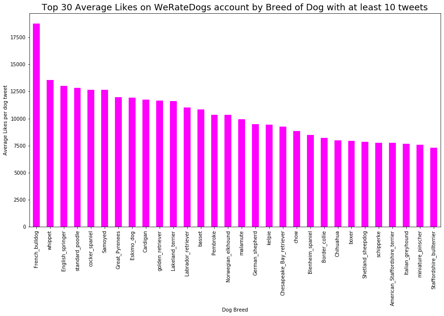

```python
from IPython.display import Image
Image("bar.png")
```